# Numerical Methods of Accelerator Physics

## Deep Q-learning (DQN)

- **Main idea:** replace the Q-table by a simple, feed-forward neural network (Q-net)
- Developed by DeepMind in 2013 to play Atari games *([DQN paper](https://arxiv.org/abs/1312.5602))*
- A neural network (NN) is a **universal function approximator**, i.e. a fit model that can approximate any function (in theory)
- The Q-net is a **mapping** from **state to Q-values** of all possible actions
- Its parameters aka. weights are adjusted according to the **TD rule**, like the Q-table

[figure not shown]

**Exercise 6**

**a)** Repeat the same steps as in Ex. 4 for the Q-table learner, but this time using `q_function='net'` as an argument in the `QLearner` class. Train it for `1500` episodes. This will take a couple of minutes.

**b)** Compare the Q-values and policy to the one obtained with Q-table learning. Do you see differences? Why could that be?

```python
from qlearning.core import Maze, QLearner
import tensorflow as tf

tf.keras.utils.set_random_seed(0)

env = Maze(width=4, height=3, fire_positions=[[2, 1], [2, 2]])
qnet_learner = QLearner(env, q_function='net') # FILL HERE)
qnet_learner.train(1500) # FILL HERE)
```

```python
# Again, if you face any issues with model training, please use
# the saved q-net weights of a trained agent by uncommenting
# the following. You can comment the line for training in the
# previous cell.

# qnet_learner.q_func.load_model('saved_agents/qnet_ex6')
```

[figure not shown]

```python
from qlearning.plot_utils import plot_q_table, plot_greedy_policy

q_table = qnet_learner.q_func.get_q_table()
ax = env.plot(add_player_position=False, title=False)
plot_q_table(q_table, env.target_position, env.fire_positions, ax=ax)
```

[figure not shown]

```python
policy = qnet_learner.q_func.get_greedy_policy()
ax = env.plot(add_player_position=False, title=False)
plot_greedy_policy(policy, env.target_position, env.fire_positions, ax=ax)
```

## Q-table vs DQN: pros, cons, and limitations

- **Q-table**
  - Easy to understand and validate
  - Discrete $S$, $A$ spaces only
  - Relatively small $S$, $A$ spaces only
- **DQN**
  - Big and continuous $S$ possible
  - No need to visit all states during training, because NNs are great interpolators
  - Discrete and relatively small $A$
  - Training may be unstable and harder to verify if we have reached convergence
- Many real-world problems require **continuous $S$ *and* continuous $A$** $\,\,\Rightarrow\,\,$ **actor-critic methods**

## Part IV: actor-critic methods

## Actor-critic scheme

- **Two NNs**
- **Actor**
  - Represents the policy $\pi$ and is a mapping $\pi: S \rightarrow A$
  - For each **continuous state**, it proposes a **continuous action**
  - Learns from the critic
- **Critic**
  - Predicts Q-values and is a mapping $Q: S\times A \rightarrow \mathbb{R}$
  - Evaluates quality of $(s, a)$ pair proposed by actor
  - Feeds back to the actor network: policy gradient rule

*N.B.: networks are trained simultaneously*

[figure not shown]

- **Critic parameters** $\theta$ are updated according to the **TD rule**, just like in Q-learning
- **Actor parameters** $\chi$ are updated via **policy gradient**: for a given state $s$, how does the actor have to adjust its parameters to propose an action $a$ such that $Q(s,a)$ becomes larger?

## Application in accelerator physics

- We are going to consider a **trajectory steering problem** from CERN's **AWAKE**
- [Advanced Proton Driven Plasma Wakefield Acceleration Experiment](https://www.nature.com/articles/s41586-018-0485-4)

[figure not shown]

image by [AWAKE Collaboration](https://www.nature.com/articles/s41586-018-0485-4)

### AWAKE electron beam line

[figure not shown]

### RL task definitions

- **Goal:** given measured beam positions *(= continuous state)*, find best dipole corrector settings *(= continuous actions)* to keep beam close to the center of vacuum pipe
- **State:** 10-d array of beam positions measured along the line
- **Action:** 10-d array of dipole corrector strengths along the line
- **Reward:** negative rms of beam offsets wrt. center

[figure not shown]

**Exercise 7**

**Let's try to train an actor-critic agent on the AWAKE environment!** We are using the **DDPG** *([Deep Deterministic Policy Gradient](https://spinningup.openai.com/en/latest/algorithms/ddpg.html))* algorithm. It is one of the most basic actor-critic algorithms and hence also not the most stable one. Some improvements have been implemented in TD3.

**7 a)** Run the following cell to initialize the AWAKE simulation environment `env` and a DDPG instance `agent`. Then reset the environment to misteer the beam, and plot the trajectory. The plot shows the beam position at the 10 BPMs installed along the electron beam line.

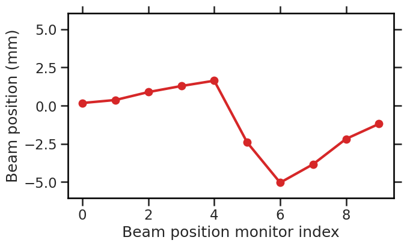

```python
# Exercise 7 a)
from actor_critic.awake_env import e_trajectory
from actor_critic.core import ClassicalDDPG, trainer, plot_training_log, run_correction
import tensorflow as tf

tf.keras.utils.set_random_seed(12345)

env = e_trajectory()
agent = ClassicalDDPG(state_space=env.observation_space, action_space=env.action_space)

env.reset(init_outside_threshold=True)
env.plot_trajectory()
```

**7 b)** Run the next cell to make a correction to the beam position. Run the cell multiple times and check how the trajectories before and after correction compare. Do you think the RL agent is doing a good job? Why or why not?

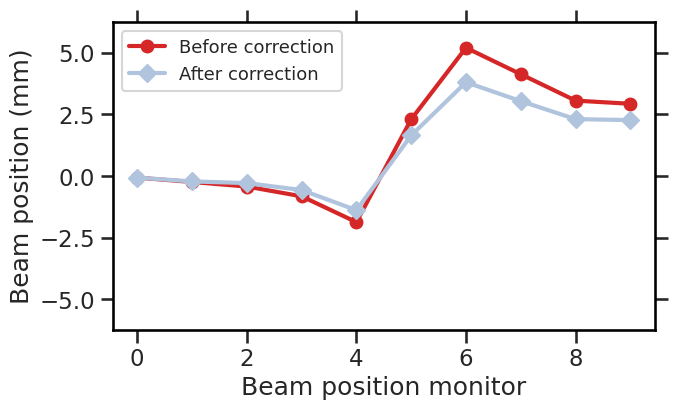

```python
# Exercise 7 b)
run_correction(env, agent)
```

**7 c)** Run the next cell to train the RL agent. Can you interpret the output plots showing evolution of agent training? Is the length of training appropriate or should we train with fewer / more steps?

*Hints: the output figure shows two axes. The top graph displays the length of each episode over the entire training period (an episode is terminated either when the objective is reached or whenever the agent cannot solve the task after 30 steps). The bottom plot shows the rewards (negative trajectory rms) at the beginning and at the end of an episode. A high negative reward means that the trajectory is badly steered. A reward close to zero on the other hand corresponds to a well-corrected beam trajectory.*

```python
# Exercise 7 c)
training_log = trainer(env=env, agent=agent, n_steps=500)
```

```
EPISODE: 0, INITIAL REWARD: -131.397, FINAL REWARD: -109.155, #STEPS: 1.
EPISODE: 50, INITIAL REWARD: -308.231, FINAL REWARD: -74.137, #STEPS: 5.
EPISODE: 100, INITIAL REWARD: -214.77, FINAL REWARD: -47.199, #STEPS: 1.
EPISODE: 150, INITIAL REWARD: -349.32, FINAL REWARD: -8.142, #STEPS: 1.
EPISODE: 200, INITIAL REWARD: -117.818, FINAL REWARD: -60.099, #STEPS: 1.
EPISODE: 250, INITIAL REWARD: -52.63, FINAL REWARD: -5.303, #STEPS: 1.
```

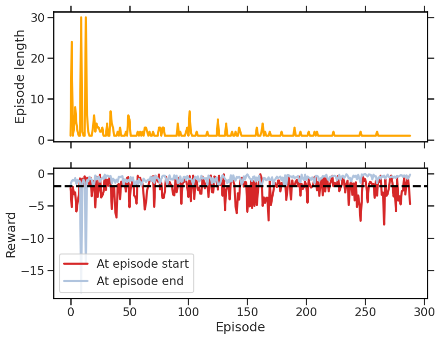

```python
plot_training_log(env, agent, training_log)
```

```python
# In case you face any issues with the training of the agent,
# avoid executing the previous cell and use instead the
# following line to load pre-trained weights.

# agent.load_actor_critic_weights('saved_agents/ddpg_ex7')
```

**7 d)** Check a few trajectories before and after correction now using the trained agent (run the cell multiple times). How does the agent perform now?

*Note that we are using the DDPG algorithm here which is one of the most basic actor-critic RL algorithms. This is also the reason why the trajectory correction will not always be perfect. There are much improved versions that would train in a shorter time and with better performance (e.g. [Twin Delayed DDPG](https://spinningup.openai.com/en/latest/algorithms/td3.html) aka TD3).*

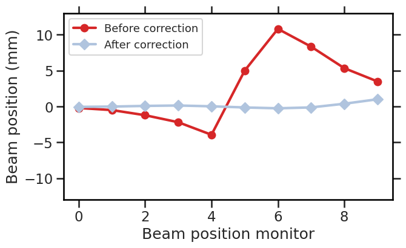

```python
# Exercise 7 d)
run_correction(env, agent)
```

## Summary

- Reinforcement learning (RL) is concerned with **solving decision-making problems** and optimizing for **best behavior** in an environment
- **Different algorithms** exist with Q-learning being one of the fundamental ones
- **Q-learning uses a state-action value function $Q(s,a)$** that estimates the expected return
- $Q(s, a)$ is iteratively learned following the **temporal difference rule**
- Once converged we can **read off the optimal policy by acting greedily** with respect to Q
- **Q-learning**
  - Lookup table: only works for **discrete state-action spaces**
  - Q-net (neural network): can deal with **continuous states**
- **Actor-critic** methods are built on top of Q-learning and use **two networks**:
  - One for the policy (actor) and one to estimate the Q-values (critic)
  - They can solve tasks with **continuous states *and* actions**.

## Comprehension questions

- What do Q-values represent?
- Why does the Q-table only work for discrete state space?
- Why does Q-learning only work for discrete action spaces, both for the Q-table and the Q-net?
- How can you obtain the optimal policy once you know the Q-values?
- Do you have to increase or decrease the discount factor $\gamma$ to put more emphasis on future rewards?
- What is the Markov property? Is it fulfilled for the maze environment? Why, or why not? (*hint: think about whether it matters for the future evolution how you ended up on the current field of the maze*)
- For the temporal difference learning update, how many different states are involved?

## Literature

- R.S. Sutton and A.G. Barto, ["Reinforcement learning - an introduction"](http://incompleteideas.net/book/RLbook2020.pdf), Book, 2nd edition, 2020.
- S. Levine, [Deep Reinforcement Learning](https://rail.eecs.berkeley.edu/deeprlcourse/), Lecture, UC Berkeley, 2022.
- D. Silver, [Reinforcement learning](https://www.davidsilver.uk/teaching/), Lecture, University College London (UCL), 2015.

## Python RL libraries

- Stable baselines 3: [github](https://github.com/DLR-RM/stable-baselines3), [docs](https://stable-baselines3.readthedocs.io/en/master/)
- OpenAI gym: [github](https://github.com/openai/gym), [docs](https://www.gymlibrary.dev/)